# Appendix D — Algebra of Graphics

In this appendix, we give a demonstration of and introduction to the [`AlgebraOfGraphics`](https://aog.makie.org/) package and plotting system. The key concepts in `AlgebraOfGraphics` (or AoG for short) are layers, the `+` operator, and the `*` operator. Each layer in an AoG plot consists of at least (1) a mapping from the data to the plot elements (such as the x-axis, y-axis, and color), and (2) a visual that defines the type of plot (for example, scatterplot or lines), which are combined using the `*` operator. The mapping is analogous to the “aesthetic mapping” in the grammar-of-graphics based [`ggplot2`](https://ggplot2.tidyverse.org) package in `R` and the visual is the same as a “geom”. While the `+` operator allows us to stack layers together, the `*` operator allows us to both construct a layer and modify multiple layers at once. Once we have constructed the layers of a plot, we can display or print the plot using the `draw` function. Additionally, the draw function allows us to apply modifications that do not depend on the data to common elements in the plot. While this may all sound very abstract we will see these concepts in action shortly.

## D.1 A plot with a single layer

To illustrate the principles briefly explained above, we plot the `elstongrizzle` dataset in multiple ways building up to the plots in Chapter 3. We start off we first plot the length of Ramus bone against time for all subjects. To do so we first load all the relevant packages,

```julia
using AlgebraOfGraphics
using CairoMakie
using DataFrames, DataFrameMacros
using GLM # for the lm needed to arrange the final plot
using EmbraceUncertainty: dataset
```

and the dataset:

```julia
elstongrizzle = DataFrame(dataset(:elstongrizzle))
```

The scatter-plot is defined by the mapping from the data to the $x$ and $y$ axis of the plots.

```julia
ramusscatter = data(elstongrizzle) * mapping(:time, :resp) * visual(Scatter)
```

```
Layer
  transformation: AlgebraOfGraphics.Visual(Scatter, {})
  data: AlgebraOfGraphics.Columns{DataFrames.DataFrameColumns{DataFrame}}
  positional:
    1: time
    2: resp
  named:
```

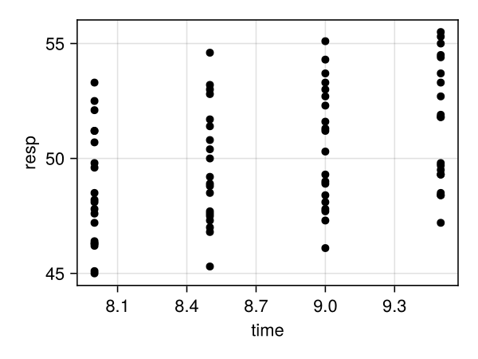

```julia
draw(ramusscatter)
```

This plot is not very useful because the points for all the subjects are mixed in together. To distinguish data for different subjects, let’s color the data points by subject. This means that we must map the subject ID (`Subj`) to the `color` attribute of the plot.

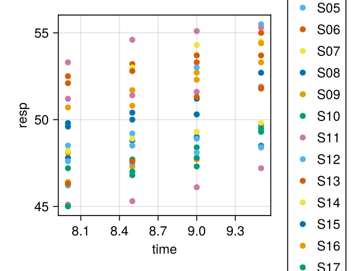

```julia
draw(ramusscatter*mapping(color = :Subj))
```

Although this worked, the more concise way to achieve the same thing is to define all the mappings at once as follows:

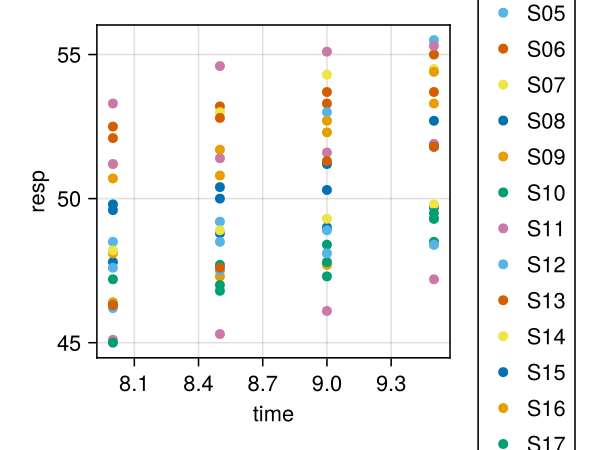

```julia
egscatter = data(elstongrizzle) *
    mapping(:time, :resp, color = :Subj) *
    visual(Scatter)
draw(egscatter)
```

## D.2 Adding another layer

To construct a layer for lines, we can use the `visual(Lines)`:

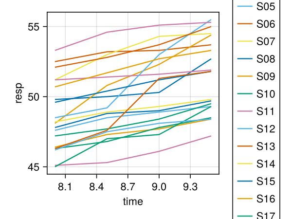

```julia
eglines = data(elstongrizzle) *
    mapping(:time, :resp, color = :Subj) *
    visual(Lines)

draw(eglines)
```

We can now combine the layers by simply using `+`!

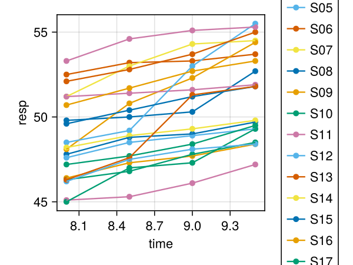

```julia
draw(egscatter + eglines)
```

You may have noticed that the mapping from the data to the plot elements is the same for both layers is the same. This is where the power of the algebra comes in. We can define two layers with the same mapping using the following code:

```julia
egscatterlines = data(elstongrizzle) *
                    mapping(:time, :resp, color = :Subj) *
                    (visual(Scatter) + visual(Lines))
```

```
Layers with 2 elements:
  Layer 1
    transformation: AlgebraOfGraphics.Visual(Scatter, {})
    data: AlgebraOfGraphics.Columns{DataFrames.DataFrameColumns{DataFrame}}
    positional:
      1: time
      2: resp
    named:
      color: Subj
  Layer 2
    transformation: AlgebraOfGraphics.Visual(Lines, {})
    data: AlgebraOfGraphics.Columns{DataFrames.DataFrameColumns{DataFrame}}
    positional:
      1: time
      2: resp
    named:
      color: Subj
```

Let’s unpack this. We can define two partial layers with `visual(Scatter) + visual(Lines)` and both are defined with the common mapping, which we can achieve by modifying, i.e. using the `*` operator on the stack of two (partial) layers. To confirm if this actually works, we can just invoke `draw`:

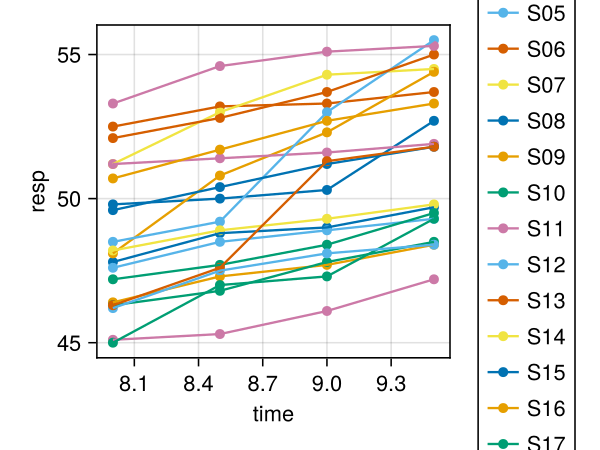

```julia
draw(egscatterlines)
```

and *voila* we just created two layers at once!

## D.3 Modifying common elements with `draw`

One issue with the plot above is that the legend is far too big to fit vertically on the side. So let’s try putting at the bottom of the plot. This is an action that is not related to any single layer, and can be modified using optional arguments to the draw method as follows:

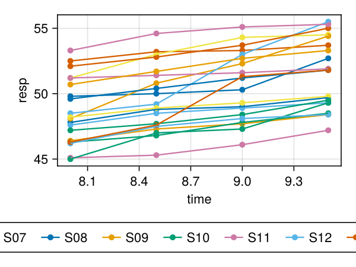

```julia
draw(
  egscatterlines;
  legend = (; position = :bottom, titleposition = :left)
)
```

Note that we reused the object `egscatterlines` which is a stack of layers from before. While this is better than before, the individual subject names are not really relevant to this plot, so let’s remove the legend altogether.

**Note**

**TODO:** How to explain why legend is disabled in the `scales`?

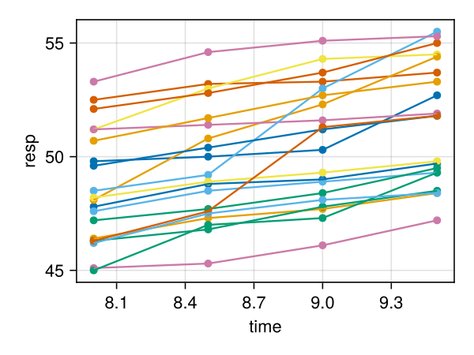

```julia
draw(
  egscatterlines,
  scales(Color = (; legend = false))
)
```

The `scales` argument can also be used to modify other features of plot elements. To demonstrate this, we change the color palette used for plotting to `darktest` color palette (See [`Makie.jl` documentation](https://docs.makie.org/stable/explanations/colors#misc)).

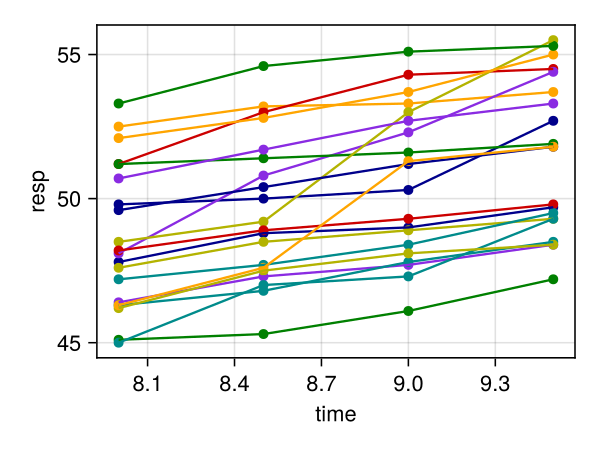

Figure D.1: Scatter-plot with overlaid lines using the `darktest` colorscheme

```julia
draw(
  egscatterlines,
  scales(Color = (; legend = false, palette = :darktest))
)
```

## D.4 Faceting

Figure D.1 is still crowded, and one way to fix this would be to plot each subject in a separate panel. In `ggplot2` this is achieved by using `facet`. Since we want to facet by `Subj`, we need to map a feature of the data (`Subj`) to an element of the plot. Thus, we must define some sort of mapping to achieve this. In this case, we want to use the equivalent of `ggplot2::facet_wrap`, which is the `layout` element of the feature. Similar to mapping the subject ID to color, we can map `Subj` to `layout` as follows:

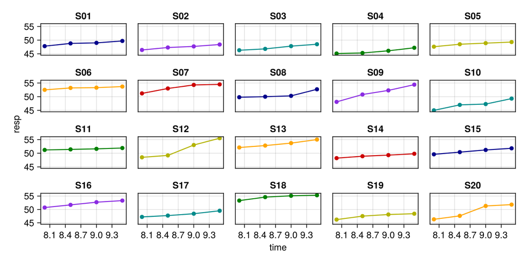

```julia
draw(
  egscatterlines * mapping(layout = :Subj),
  scales(Color = (; legend = false, palette = :darktest));
  figure = (; size = (800, 400))
)
```

It is also possible to facet by two features, one along the horizontal direction and one along the vertical direction using the `col` and `row` (this would be akin to `ggplot2::facet_grid`) keyword arguments in the mapping.

**Note**

**TODO:** use the `layout` keyword mapping to create facets by subject instead of colors by subject